# Exemplos - Testes de Hipoteses Não Parametricos

[figure not shown]

## Códigos - Testes de Hipóteses Não paramétricos

### Disciplina - Inferência Estatística - Professora - Ana Carolina Dias

```python
import scipy.stats as st
from statistics import mean, stdev
from statsmodels.stats.weightstats import ztest
import statsmodels.api as sm
from scipy.stats import normaltest , norm, shapiro
import numpy as np
import pandas as pd

import warnings
warnings.filterwarnings("ignore", category=DeprecationWarning)

import seaborn as sns
import matplotlib.pyplot as plt
```

# Teste de Hipótese Qui-quadrado

# Exemplo - Teste de Homogeneidade - Luvas

Para isto, realizou um experimento, no qual 240 luvas da marca A, 240 luvas da marca B e 300 luvas da marca C foram submetidas à tensão.

Durante os testes, 151 luvas da marca A (62.9%), 134 luvas da marca B (55.8%) e 177 luvas da marca C (59.0%) deixaram passar vírus.

Os dados do experimento apresentam evidências estatísticas suficientes contra a hipótese de que as três marcas possuem a mesma permeabilidade?

$$\begin{cases} H_0 = p_1 = p_2 = p_3\\H_1 = \text{Pelo menos uma é diferente}\end{cases} $$

```python
Luvas = pd.read_csv('Permeabilidade_Luvas.csv', sep= ',')
Luvas
```

|  | Luva | Resposta |
| --- | --- | --- |
| 0 | A | Sim |
| 1 | A | Sim |
| 2 | A | Sim |
| 3 | A | Sim |
| 4 | A | Sim |
| ... | ... | ... |
| 775 | C | Nao |
| 776 | C | Nao |
| 777 | C | Nao |
| 778 | C | Nao |
| 779 | C | Nao |

780 rows × 2 columns

```python
tabela_cont = pd.crosstab(Luvas.Luva, Luvas.Resposta, margins=True)
tabela_cont
```

| Resposta Luva | Nao | Sim | All |
| --- | --- | --- | --- |
| A | 89 | 151 | 240 |
| B | 106 | 134 | 240 |
| C | 123 | 177 | 300 |
| All | 318 | 462 | 780 |

```python
from scipy.stats import chi2_contingency

contingencia = pd.crosstab(Luvas.Luva, Luvas.Resposta, margins=False)

chi2, p, gl, Exp = chi2_contingency(contingencia, correction=True)
alpha = 0.05

# Calcular valor crític
valor_critico = st.chi2.ppf(1 - alpha, gl)

# Imprimir os resultados formatados
print("\nResultado do Teste Qui-Quadrado:")
print(f"Graus de Liberdade: {gl}")
print(f"Qui-Quadrado: {chi2:.4f}")
print(f"Valor-p: {p:.4f}")
print(f"Valor Crítico: {valor_critico:.4f}")
print(f"Valores Esperados: {Exp}")

# Verificar se rejeitamos a hipótese nula
print("\nConclusão:")
if abs(chi2) > valor_critico:
    print(f"Rejeitamos a hipótese nula.")
else:
    print(f"Não temos evidências para rejeitar a hipótese nula.")
```

[output not shown]

# Teste Post-hoc qui-quadrado

### Realize Testes Qui-Quadrado Adicionais entre Pares de Categorias e ajuste o p-valor

```python
from itertools import combinations
from statsmodels.sandbox.stats.multicomp import multipletests

df = contingencia

all_combinations = list(combinations(df.index, 2))
p_vals = []

for comb in all_combinations:
    # subset df into a dataframe containing only the pair "comb"
    new_df = df[(df.index == comb[0]) | (df.index == comb[1])]
    # running chi2 test
    chi2, p, gl, ex = st.chi2_contingency(new_df, correction=True)
    p_vals.append(p)

reject_list, corrected_p_vals = multipletests(p_vals, method='fdr_bh')[:2]

print("original p-value\tcorrected p-value\treject?")
for p_val, corr_p_val, reject, comb in zip(p_vals, corrected_p_vals, reject_list, all_combinations):
        print(f"{comb}: p_value: {p_val:5f}; corrected: {corr_p_val:5f}) reject: {reject}")
```

```
original p-value	corrected p-value	reject?
('A', 'B'): p_value: 0.137024; corrected: 0.411072) reject: False
('A', 'C'): p_value: 0.402332; corrected: 0.514226) reject: False
('B', 'C'): p_value: 0.514226; corrected: 0.514226) reject: False
```

# Teste Post-hoc qui-quadrado - Exato Fisher

### Realize Testes 2x2 Pares de Categorias e ajuste o p-valor

```python
for comb in all_combinations:
    new_df = df.loc[list(comb)]

    # Running Fisher exact test
    odds_ratio, p_val = st.fisher_exact(new_df)
    p_vals.append(p_val)

reject_list, corrected_p_vals, _, _ = multipletests(p_vals, method='fdr_bh')

print("Original p-value\tCorrected p-value\tReject?")
for p_val, corr_p_val, reject, comb in zip(p_vals, corrected_p_vals, reject_list, all_combinations):
    print(f"{comb}: p_value: {p_val:.5f}; corrected: {corr_p_val:.5f}) reject: {reject}")
```

```
Original p-value	Corrected p-value	Reject?
('A', 'B'): p_value: 0.13702; corrected: 0.41107) reject: False
('A', 'C'): p_value: 0.40233; corrected: 0.51423) reject: False
('B', 'C'): p_value: 0.51423; corrected: 0.51423) reject: False
```

# Teste exato de Fisher

# Exemplo - Ameaça de suicidio

Em um estudo de situações nas quais pessoas ameaçam suicido saltando de um edifício, ponte ou torre, foi observado que ocorrem vaias e provocações por certos espectadores em alguns casos e outros não.

Várias teorias propõem que fatores como temperatura, barulho e fadiga podem contribuir com o fenômeno da provocação. Um estudo examinou 21 relatos de suicídios e investigou a relação entre provocações por multidões e o mês do ano (indicador grosseiro para temperatura). A hipótese é de que há um aumento de provocações por multidões quando faz calor.

|  | Provocação | Não provocação | Total |
| --- | --- | --- | --- |
| Junho-Setembro | 8 | 4 | 12 |
| Outubro-Maio | 2 | 7 | 9 |
| Total | 10 | 11 | 21 |

```python
from scipy.stats import fisher_exact

# Crie uma tabela de contingência 2x2
contingency_table = [[8, 4], [2, 7]]

# Realize o teste exato de Fisher
Est_testes, p_valor = fisher_exact(contingency_table, alternative='greater')

# Exiba os resultados
print("Estatística de teste:", Est_testes)
print("Valor p:", p_valor.round(3))

# Teste de significância
alpha = 0.10
if p_valor < alpha:
    print("Rejeitamos a hipótese nula")
else:
    print("Não rejeitamos a hipótese nula")
```

```
Estatística de teste: 7.0
Valor p: 0.056
Rejeitamos a hipótese nula
```

# Teste da Mediana

# Exemplo - Salários

Os dados apresentam a quantidade de salários mínimos dos funcionários de uma empresa de dois setores: Recursos Humanos e Controle de Qualidade. Verifique se os salários do RH provém de populações com mediana maior do que da população de CQ.

| RH | CQ |
| --- | --- |
| 4 | 11 |
| 3 | 10 |
| 8 | 7 |
| 3 | 6 |
| 5 | 5 |
| 7 | 8 |
| 2 | 9 |
|  | 10 |

```python
# Crie uma tabela de contingência 2x2
contingency_table = [[1, 5], [6, 3]]

# Realize o teste exato de Fisher
Est_testes, p_valor = fisher_exact(contingency_table, alternative='greater')

# Exiba os resultados
print("Estatística de teste:", Est_testes)
print("Valor p:", p_valor.round(3))

# Teste de significância
alpha = 0.10
if p_valor < alpha:
    print("Rejeitamos a hipótese nula")
else:
    print("Não rejeitamos a hipótese nula")
```

```
Estatística de teste: 0.1
Valor p: 0.994
Não rejeitamos a hipótese nula
```

# Exemplo: Inteligência emocional

Nos mesmos dois setores da empresa citada anteriormente, registrou-se os escores de um teste de inteligência emocional. Verifique a hipótese de que as amostras provêm de populações com a mesma mediana.

| RH | CQ |
| --- | --- |
| 15 | 8 |
| 12 | 7 |
| 13 | 14 |
| 9 | 10 |
| 18 | 8 |
| 11 | 6 |
| 12 | 7 |
| 13 | 6 |
| 14 | 8 |
| 14 | 4 |
| 12 |  |
| 12 |  |
| 10 |  |
| 11 |  |

```python
# Crie uma tabela de contingência 2x2
contingency_table = [[10, 1], [4, 9]]

chi2, p, gl, Exp = chi2_contingency(contingency_table)
alpha = 0.05

# Calcular valor crític
valor_critico = st.chi2.ppf(1 - alpha, gl)

# Imprimir os resultados formatados
print("\nResultado do Teste Qui-Quadrado:")
print(f"Graus de Liberdade: {gl}")
print(f"Qui-Quadrado: {chi2:.4f}")
print(f"Valor-p: {p:.4f}")
print(f"Valor Crítico: {valor_critico:.4f}")

# Verificar se rejeitamos a hipótese nula
print("\nConclusão:")
if abs(chi2) > valor_critico:
    print(f"Rejeitamos a hipótese nula.")
else:
    print(f"Não temos evidências para rejeitar a hipótese nula.")
```

```
Resultado do Teste Qui-Quadrado:
Graus de Liberdade: 1
Qui-Quadrado: 6.5646
Valor-p: 0.0104
Valor Crítico: 3.8415

Conclusão:
Rejeitamos a hipótese nula.
```

# Teste de Hipótese McNemar

# Exemplo - Candidatos

Numa campanha política, após uma série de fatos que supostamente difamaram a imagem do candidato B em favor do candidato A, investigou-se as mudanças ocorridas com relação à preferência do eleitorado.

O que podemos concluir com os dados observados a um nível de 5%?

|  | Candidato A | Candidato B |
| --- | --- | --- |
| Candidato A | 83 | 47 |
| Candidato B | 18 | 52 |

$$\begin{cases} H_0 = \text{Não há diferença estatisticamente significativa nas proporções das categorias discordantes}\\H_1 = \text{Há uma diferença significativa}\end{cases} $$

```python
import statsmodels.stats.contingency_tables as contingency

# Tabela de contingência 2x2 para dados pareados
table = np.array([[83, 47],
                  [18, 52]])


# If exact is true, then the binomial distribution will be used.
# If exact is false, then the chisquare distribution will be used.

# Realiza o teste de McNemar
result = contingency.mcnemar(table, exact=False, correction=True)

# Imprime os resultados
print("\nResultado do Teste de McNemar:")
print(f"Estatística de McNemar: {result.statistic:.4f}")
print(f"Valor p: {result.pvalue:.4f}")

print("\nConclusão:")
if result.pvalue < 0.05:
    print("Rejeitamos a hipótese nula.")
    if table[1, 0] + table[1, 1] < 10:
        print("Nota: A suposição b + c >= 10 não é atendida.")
else:
    print("Não temos evidências para rejeitar a hipótese nula.")
```

```
Resultado do Teste de McNemar:
Estatística de McNemar: 12.0615
Valor p: 0.0005

Conclusão:
Rejeitamos a hipótese nula.
```

# Exemplo - Nota dos alunos

Suponhamos que estamos conduzindo uma investigação para avaliar a eficácia de dois métodos de ensino (A e B) na melhoria do desempenho dos alunos em um teste de Estatística. Para realizar essa análise, coletamos dados antes e depois da aplicação dos métodos de ensino.

Na tabela abaixo temos a quantidade de alunos com notas mais altas ou não do que a média da prova.

[output not shown]

```python
dados_tratamentos = pd.read_csv('dados_metodoEnsino.csv', sep= ',')
dados_tratamentos
```

|  | Aluno | Metodo_A | Metodo_B |
| --- | --- | --- | --- |
| 0 | 1 | Melhorou | Melhorou |
| 1 | 2 | Melhorou | Não Melhorou |
| 2 | 3 | Melhorou | Não Melhorou |
| 3 | 4 | Melhorou | Melhorou |
| 4 | 5 | Não Melhorou | Melhorou |
| ... | ... | ... | ... |
| 145 | 146 | Não Melhorou | Melhorou |
| 146 | 147 | Melhorou | Melhorou |
| 147 | 148 | Melhorou | Não Melhorou |
| 148 | 149 | Não Melhorou | Melhorou |
| 149 | 150 | Melhorou | Não Melhorou |

150 rows × 3 columns

```python
# Tabela de contingência 2x2 para dados pareados
tabela_contingencia = pd.crosstab(dados_tratamentos['Metodo_A'], dados_tratamentos['Metodo_B'], margins=False)


# If exact is true, then the binomial distribution will be used.
# If exact is false, then the chisquare distribution will be used.

# Realiza o teste de McNemar
result = contingency.mcnemar(tabela_contingencia, exact=False, correction=True)

# Imprime os resultados
print("\nResultado do Teste de McNemar:")
print(f"Estatística de McNemar: {result.statistic:.4f}")
print(f"Valor p: {result.pvalue:.4f}")

print("\nConclusão:")
if result.pvalue < 0.05:
    print("Rejeitamos a hipótese nula.")
    if table[1, 0] + table[1, 1] < 10:
        print("Nota: A suposição b + c >= 10 não é atendida.")
else:
    print("Não temos evidências para rejeitar a hipótese nula.")
```

```
Resultado do Teste de McNemar:
Estatística de McNemar: 7.2239
Valor p: 0.0072

Conclusão:
Rejeitamos a hipótese nula.
```

# Teste Binomial

Duas amostras pareadas

# Exemplo - Supermercado

Dois supermercados disputam a preferência dos consumidores de uma cidade. O supermercado A realiza então uma campanha com distribuição de prêmios para aumentar o número de fregueses. 100 consumidores foram acompanhados antes e depois da campanha, onde perguntou-se a cada um deles sobre a sua preferência. Os resultados seguem abaixo. Utilize α=0,05.

|  | A | B | Total |
| --- | --- | --- | --- |
| A | 37 | 3 | 40 |
| B | 13 | 47 | 60 |
| Total | 50 | 50 | 100 |

```python
from scipy.stats import binom_test
n = 16
x = 3
p0 = 0.5
p_valor  = binom_test(x=x, n=n, p=p0, alternative='less')

# Exiba o resultado
print("Valor p:", p_valor.round(3))

# Teste de significância
alpha = 0.05
if p_valor < alpha:
    print("Rejeitamos a hipótese nula.")
else:
    print("Não rejeitamos a hipótese nula.")
```

```
Valor p: 0.011
Rejeitamos a hipótese nula.
```

# Teste Binomial

Uma amostra n<=35

# Exemplo - Emagrecimento

Uma empresa lançou recentemente no mercado uma dieta de emagrecimento. E pretende-se averiguar se a proporção de consumidores com idades superiores a 60 anos é maior que 0.2.

Para tal procedeu na escolha aleatória de 20 indivíduos entre os adeptos da nova dieta, e apurou que apenas 5 tinham idade superior a 60 anos. Utilize α=0,05.

```python
n = 20
x = 5
p0 = 0.2
p_valor  = binom_test(x=x, n=n, p=p0, alternative='greater')

# Exiba o resultado
print("Valor p:", p_valor.round(3))

# Teste de significância
alpha = 0.05
if p_valor < alpha:
    print("Rejeitamos a hipótese nula.")
else:
    print("Não rejeitamos a hipótese nula.")
```

```
Valor p: 0.37
Não rejeitamos a hipótese nula.
```

# Teste de Postos com Sinais de Wilcoxon

### Duas amostras pareadas

# Exemplo - Colheita de Milho

Os dados a seguir são das colheitas de espigas de milho (em libras por acre) de dois diferentes tipos de sementes (normais e secas no forno) que foram usados em lotes adjacentes. Usando o teste dos wilcoxom, verifique se há diferença entre as colheitas de milho de semente normal e semente secada no forno. Utilizar α=0,05.

| Normal | Seca |
| --- | --- |
| 1903 | 2009 |
| 1935 | 1915 |
| 1910 | 2011 |
| 2496 | 2463 |
| 2108 | 2180 |
| 1961 | 1925 |
| 2060 | 2122 |
| 1444 | 1482 |
| 1612 | 1542 |
| 1316 | 1443 |
| 1511 | 1535 |

```python
from scipy.stats import wilcoxon

# Dados das amostras pareadas
normal = [1903, 1935, 1910, 2496, 2108, 1961, 2060, 1444, 1612, 1316, 1511]
seca = [2009, 1915, 2011, 2463, 2180, 1925, 2122, 1482, 1542, 1443, 1535]

# O erro de arredondamento na subtração pode resultar na atribuição de diferentes
# classificações aos elementos, mesmo quando estariam empatados com a aritmética exata.
# Em vez de passar x e y separadamente, considere calcular a diferença

stat, p_valor = wilcoxon(normal, seca, zero_method='wilcox', correction=False, alternative='two-sided', method = 'auto')

# Exibe os resultados
print("Estatística do teste:", stat)
print("Valor p:", p_valor)

# Teste de significância
alpha = 0.05
if p_valor < alpha:
    print("Rejeitamos a hipótese nula")
else:
    print("Não rejeitamos a hipótese nula")
```

[output not shown]

### Passando as diferenças para a função

```python
diferencas = [normal[i] - seca[i] for i in range(len(normal))]
diferencas

# Realiza o teste de Wilcoxon para amostras pareadas
# “wilcox”: Descarta todas as diferenças = zero
stat, p_valor = wilcoxon(diferencas, zero_method='wilcox', correction=False, alternative='two-sided')

# Exibe os resultados
print("Estatística do teste:", stat)
print("Valor p:", p_valor)

# Teste de significância
alpha = 0.05
if p_valor < alpha:
    print("Rejeitamos a hipótese nula")
else:
    print("Não rejeitamos a hipótese nula")
```

```
Estatística do teste: 15.0
Valor p: 0.123046875
Não rejeitamos a hipótese nula
```

# Exemplo - Notas dos alunos

H0: Método não eficiente. Nota 2 = Nota 1. A mediana das diferenças é igual a 0.

H1: Método é eficiente. Nota 2 > Nota 1. A mediana das diferenças é > 0.

```python
NovoMetodo = pd.read_csv('Notas_teste_NP.csv', sep= ';')
NovoMetodo.head(10)
```

|  | Aluno | Nota 1 | Nota 2 |
| --- | --- | --- | --- |
| 0 | 1 | 5.1 | 5.8 |
| 1 | 2 | 4.2 | 4.7 |
| 2 | 3 | 3.3 | 6.1 |
| 3 | 4 | 6.0 | 7.4 |
| 4 | 5 | 7.1 | 6.5 |
| 5 | 6 | 3.2 | 3.2 |
| 6 | 7 | 2.8 | 4.5 |
| 7 | 8 | 1.4 | 3.5 |
| 8 | 9 | 0.8 | 4.0 |
| 9 | 10 | 5.6 | 5.5 |

```python
diferenca = NovoMetodo['Nota 1'] - NovoMetodo['Nota 2']
diferenca
```

```
0    -0.7
1    -0.5
2    -2.8
3    -1.4
4     0.6
5     0.0
6    -1.7
7    -2.1
8    -3.2
9     0.1
10   -0.1
11    0.2
12    1.2
13    0.0
14   -4.8
15   -2.8
16   -0.3
17    3.6
18    0.3
19   -0.8
20   -0.7
21   -0.5
22   -3.3
23   -0.3
24    1.7
25   -5.1
dtype: float64
```

```python
# O pacote usa o padrão n > 50 para usar o teste z

stat, p_valor  = wilcoxon(diferenca,
                         zero_method='wilcox', correction=True, alternative='less', method = 'approx')

# Exibe os resultados
print("Estatística do teste - T:", stat)
print("Valor p:", p_valor)

# Teste de significância
alpha = 0.05
if p_valor < alpha:
    print("Rejeitamos a hipótese nula")
else:
    print("Não rejeitamos a hipótese nula")
```

```
Estatística do teste - T: 67.5
Valor p: 0.009556096058477008
Rejeitamos a hipótese nula
```

## Uma amostra

```python
from scipy.stats import wilcoxon

# Amostra de dados
amostra = [10.5, 7.5, 18.5, 14, 9, 0, 15.5, 17, 20, 1.5, 1.5, 3, 13, 0, 23, 18.5, 5, 22, 5, 12, 10.5, 7.5, 21, 5, 15.5, 24]

# Valor de referência (hipótese nula: mediana igual a este valor)
valor_referencia = 10

# Calcula as diferenças entre cada valor e a constante
diferencas = [x - valor_referencia for x in amostra]


# Realiza o teste de Wilcoxon para uma amostra
stat, p_valor = wilcoxon(diferencas, zero_method='wilcox', correction=False, alternative='less', method = 'auto')

# Exibe os resultados
print("Estatística do teste:", stat)
print("Valor p:", p_valor)

# Teste de significância
alpha = 0.05
if p_valor < alpha:
    print("Rejeitamos a hipótese nula")
else:
    print("Não rejeitamos a hipótese nula")
```

```
Estatística do teste: 215.5
Valor p: 0.8423742800951004
Não rejeitamos a hipótese nula
```

# Teste Wilcoxon Mann-Whitney

Mann-Whitney U

Duas amostras independentes

### Amostras pequenas

# Exemplo - Aprendizado de Ratos

A comparação é feita em termos de quantos ensaios cada rato executou para chegar ao critério de 10 respostas corretas em 10 ensaios.

| Grupo experimental | Grupo controle |
| --- | --- |
| 110 | 78 |
| 70 | 64 |
| 53 | 75 |
| 51 | 45 |
|  | 82 |

```python
from scipy.stats import mannwhitneyu

# Duas amostras independentes
grupo_experimental = [110,70,53,51]
grupo_controle = [78,64,75,45,82]

# Teste de Mann-Whitney U
U, p_valor = mannwhitneyu(grupo_experimental, grupo_controle, use_continuity=True, alternative='greater', method='exact')

# Exibir os resultados
print("Estatística do teste de Mann-Whitney U:", U)
print("Valor p:", p_valor.round(3))

# Teste de significância
alpha = 0.05
if p_valor < alpha:
    print("Rejeitamos a hipótese nula")
else:
    print("Não rejeitamos a hipótese nula")
```

```
Estatística do teste de Mann-Whitney U: 9.0
Valor p: 0.635
Não rejeitamos a hipótese nula
```

### Amostras grandes

Vamos comparar as notas de física dos alunos de rede pública e privada. Nosso objetivo é entender se as escolas públicas e privadas possuem a mesma mediana de notas para a disciplina de Física.

```python
dados_alunos = pd.read_csv('Alunos_publica_privada.csv', sep= ';', decimal= ',')
dados_alunos.head()
```

|  | Sujeito | Genero | Escola | Posicao_Sala | Nota_Biol | Nota_Fis | Nota_Hist |
| --- | --- | --- | --- | --- | --- | --- | --- |
| 0 | 1 | M | Privada | Fundos | 8.1 | 4.6 | 2.9 |
| 1 | 2 | F | Privada | Fundos | 5.3 | 4.9 | 6.4 |
| 2 | 3 | M | Publica | Fundos | 2.9 | 3.7 | 3.1 |
| 3 | 4 | M | Publica | Fundos | 3.7 | 3.8 | 4.9 |
| 4 | 5 | F | Publica | Fundos | 4.4 | 4.2 | 4.9 |

```python
from scipy.stats import mannwhitneyu

# Duas amostras independentes
Privada = dados_alunos[dados_alunos.Escola == 'Privada']['Nota_Fis']
Publica = dados_alunos[dados_alunos.Escola == 'Publica']['Nota_Fis']

# Teste de Mann-Whitney U
U, p_valor = mannwhitneyu(Privada, Publica, use_continuity=True, alternative='two-sided', method='auto')

# Exibir os resultados
print("Estatística do teste de Mann-Whitney U:", U)
print("Valor p:", p_valor.round(3))

# Teste de significância
alpha = 0.05
if p_valor < alpha:
    print("Rejeitamos a hipótese nula")
else:
    print("Não rejeitamos a hipótese nula")
```

```
Estatística do teste de Mann-Whitney U: 192.5
Valor p: 0.016
Rejeitamos a hipótese nula
```

# Teste de Kruskall Wallis

Tres ou mais amostras independentes

# Exemplo - Autoritarismo

Um pesquisador deseja investigar o grau de autoritarismo do pessoal de escolas, usando a escala de autoritarismo de Adorno e colegas. Os escores estão apresentados abaixo. Verifique se há diferença na mediana dos grupos.

H0: Não há diferença na mediana do grau de autoritarismo dos 3 grupos.

H1: Pelo menos uma das medianas é diferentes.

| Professores E.F. | Outros Professores | Administradores |
| --- | --- | --- |
| 96 | 82 | 115 |
| 128 | 124 | 149 |
| 83 | 132 | 166 |
| 61 | 135 | 147 |
| 101 | 109 | 165 |

```python
from scipy.stats import kruskal

# Três grupos independentes
ProfEf = [96,128,83,61,101]
OutroProfessores = [82,124,132,135,109]
Admin = [115,149,166,147,165]

# Teste de Kruskal-Wallis
stat, p_valor = kruskal(ProfEf, OutroProfessores, Admin)

# Exibir os resultados
print("Estatística do teste de Kruskal-Wallis:", stat.round(3))
print("Valor p:", p_valor.round(3))

# Teste de significância
alpha = 0.05
if p_valor < alpha:
    print("Rejeitamos a hipótese nula")
else:
    print("Não rejeitamos a hipótese nula")
```

```
Estatística do teste de Kruskal-Wallis: 7.74
Valor p: 0.021
Rejeitamos a hipótese nula
```

### Pacote pingouin

```python
dados = pd.DataFrame({
    'ProfEf': ProfEf,
    'OutroProfessores': OutroProfessores,
    'Admin': Admin
})

dados_pivotados = pd.melt(dados, var_name='Grupo', value_name='Grau')
dados_pivotados
```

|  | Grupo | Grau |
| --- | --- | --- |
| 0 | ProfEf | 96 |
| 1 | ProfEf | 128 |
| 2 | ProfEf | 83 |
| 3 | ProfEf | 61 |
| 4 | ProfEf | 101 |
| 5 | OutroProfessores | 82 |
| 6 | OutroProfessores | 124 |
| 7 | OutroProfessores | 132 |
| 8 | OutroProfessores | 135 |
| 9 | OutroProfessores | 109 |
| 10 | Admin | 115 |
| 11 | Admin | 149 |
| 12 | Admin | 166 |
| 13 | Admin | 147 |
| 14 | Admin | 165 |

```python
import pingouin as pg

Kruskall = pg.kruskal(data = dados_pivotados, dv='Grau', between='Grupo')
Kruskall
```

|  | Source | ddof1 | H | p-unc |
| --- | --- | --- | --- | --- |
| Kruskal | Grupo | 2 | 7.74 | 0.020858 |

```python
# pip install scikit_posthocs
```

```python
from scikit_posthocs import posthoc_dunn

posthoc_dunn( dados_pivotados, val_col='Grau', group_col='Grupo', p_adjust = 'bonferroni')
```

|  | Admin | OutroProfessores | ProfEf |
| --- | --- | --- | --- |
| Admin | 1.000000 | 0.269058 | 0.017462 |
| OutroProfessores | 0.269058 | 1.000000 | 0.866533 |
| ProfEf | 0.017462 | 0.866533 | 1.000000 |

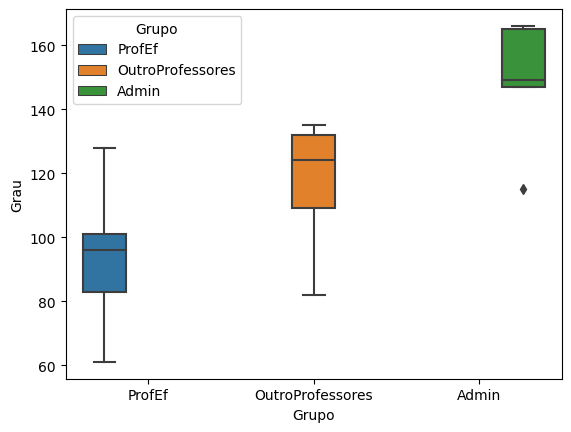

```python
sns.boxplot(x='Grupo', y='Grau', data=dados_pivotados, hue='Grupo')
```

# Teste Q-Cochran

k amostras dependentes Extensão do McNemar

# Exemplo - Atitude de um entrevistador

Deseja-se analisar a influência da atitude de um entrevistador sobre as respostas a uma pesquisa sobre opinião pública, dadas por donas de casa. Os entrevistadores são treinados de acordo com os seguintes métodos:

I – Demonstrando interesse, cordialidade, entusiasmo

II – Demonstrando formalismo, reserva e cortesia

III – Demonstrando modo abrupto, formalismo áspero.

Cada entrevistador visita 18 casas (uma casa em cada bairro) e aplica um dos métodos de abordagem.

Os resultados estão demonstrados na tabela ao lado. Obs: 0: não ; 1: sim

```python
data = {
    'Bairro': [1, 2, 3, 4, 5, 6, 7, 8, 9, 10, 11, 12, 13, 14, 15, 16, 17, 18],
    'Ent.1': [0, 1, 0, 0, 1, 1, 1, 0, 1, 0, 1, 1, 1, 1, 1, 1, 1, 1],
    'Ent.2': [0, 1, 1, 0, 0, 1, 1, 1, 0, 0, 1, 1, 1, 1, 1, 1, 1, 1],
    'Ent.3': [0, 0, 0, 0, 0, 0, 0, 0, 0, 0, 1, 1, 0, 0, 0, 1, 0, 0]
}

df = pd.DataFrame(data)

# Criar um DataFrame
dados_pivotados = pd.melt(df, id_vars='Bairro', var_name='Grupos', value_name='Resposta')
dados_pivotados.head(10)
```

|  | Bairro | Grupos | Resposta |
| --- | --- | --- | --- |
| 0 | 1 | Ent.1 | 0 |
| 1 | 2 | Ent.1 | 1 |
| 2 | 3 | Ent.1 | 0 |
| 3 | 4 | Ent.1 | 0 |
| 4 | 5 | Ent.1 | 1 |
| 5 | 6 | Ent.1 | 1 |
| 6 | 7 | Ent.1 | 1 |
| 7 | 8 | Ent.1 | 0 |
| 8 | 9 | Ent.1 | 1 |
| 9 | 10 | Ent.1 | 0 |

```python
# Realizar o teste de Cochran
pg.cochran(data=dados_pivotados, subject='Bairro', dv='Resposta', within='Grupos')
```

|  | Source | dof | Q | p-unc |
| --- | --- | --- | --- | --- |
| cochran | Grupos | 2 | 16.666667 | 0.00024 |

### Comparações múltiplas pelo McNemar com correções Bonferroni

(O python não tem é necessário implementar!!!!)

### Comparações múltiplas pelo teste de Dunn

```python
posthoc_dunn(dados_pivotados, val_col='Resposta', group_col='Grupos', p_adjust = 'bonferroni')
```

|  | Ent.1 | Ent.2 | Ent.3 |
| --- | --- | --- | --- |
| Ent.1 | 1.000000 | 1.000000 | 0.002785 |
| Ent.2 | 1.000000 | 1.000000 | 0.002785 |
| Ent.3 | 0.002785 | 0.002785 | 1.000000 |

# Teste de Friedman

ANOVA de dois fatores de Friedman por postos

k amostras dependentes

# Exemplo - Meditação

Uma pesquisa foi delineada para avaliar a eficácia de um programa para a redução do estresse baseado em meditação, para pacientes com problemas de ansiedade.

Foi medido o escore de Ansiedade da Escala Hamilton em quatro momentos diferentes: recrutamento (IR), pré-tratamento (Pré), pós-tratamento (Pós) e três meses após o pós-tratamento (3-M).

O tratamento aparenta ter surtido efeito?

```python
data = {
    'Sujeito': [1, 2, 3, 4, 5, 6, 7, 8, 9, 10, 11, 12, 13, 14],
    'IR': [21, 30, 38, 43, 35, 40, 27, 18, 31, 21, 18, 28, 40, 35],
    'Pre': [21, 38, 19, 33, 34, 40, 15, 11, 42, 23, 24, 8, 37, 32],
    'Pos': [16, 10, 15, 30, 25, 31, 11, 4, 23, 21, 16, 5, 31, 12],
    '3M': [19, 21, 6, 24, 10, 30, 6, 7, 27, 17, 13, 2, 19, 21]
}

# Criar um DataFrame
df = pd.DataFrame(data)

dados_pivotados = pd.melt(df, id_vars='Sujeito', var_name='Grupos', value_name='Escore')
dados_pivotados.head()
```

|  | Sujeito | Grupos | Escore |
| --- | --- | --- | --- |
| 0 | 1 | IR | 21 |
| 1 | 2 | IR | 30 |
| 2 | 3 | IR | 38 |
| 3 | 4 | IR | 43 |
| 4 | 5 | IR | 35 |

```python
pd.options.display.float_format = '{:.4f}'.format
pg.friedman(data=dados_pivotados, subject='Sujeito', dv='Escore', within='Grupos')
```

|  | Source | W | ddof1 | Q | p-unc |
| --- | --- | --- | --- | --- | --- |
| Friedman | Grupos | 0.8055 | 3 | 33.8321 | 0.0000 |

### Comparações múltiplas pelo teste de Wilcoxon com correção Bonferroni

```python
pg.pairwise_tests(dv='Escore', within='Grupos', subject='Sujeito',data=dados_pivotados,
                  parametric= False, padjust='bonf', alpha = 0.05)

#warnings.simplefilter(action='ignore', category=FutureWarning)
```

|  | Contrast | A | B | Paired | Parametric | W-val | alternative | p-unc | p-corr | p-adjust | hedges |
| --- | --- | --- | --- | --- | --- | --- | --- | --- | --- | --- | --- |
| 0 | Grupos | 3M | IR | True | False | 0.0000 | two-sided | 0.0001 | 0.0007 | bonf | -1.6395 |
| 1 | Grupos | 3M | Pos | True | False | 36.0000 | two-sided | 0.3258 | 1.0000 | bonf | -0.2178 |
| 2 | Grupos | 3M | Pre | True | False | 0.0000 | two-sided | 0.0001 | 0.0007 | bonf | -1.0785 |
| 3 | Grupos | IR | Pos | True | False | 0.0000 | two-sided | 0.0016 | 0.0098 | bonf | 1.3698 |
| 4 | Grupos | IR | Pre | True | False | 23.0000 | two-sided | 0.2238 | 1.0000 | bonf | 0.3357 |
| 5 | Grupos | Pos | Pre | True | False | 0.0000 | two-sided | 0.0001 | 0.0007 | bonf | -0.8632 |

```python
# import scikit_posthocs as scipost
# # Perform Wilcoxon post-hoc test pacote
# scipost. posthoc_wilcoxon(dados_pivotados, group_col='Grupos', val_col='Escore', p_adjust='bonferroni',
#                  zero_method = 'wilcox' , correction= True)
```

```python
posthoc_dunn( dados_pivotados, val_col='Escore', group_col='Grupos', p_adjust = 'bonferroni')
```

|  | 3M | IR | Pos | Pre |
| --- | --- | --- | --- | --- |
| 3M | 1.0000 | 0.0040 | 1.0000 | 0.0516 |
| IR | 0.0040 | 1.0000 | 0.0182 | 1.0000 |
| Pos | 1.0000 | 0.0182 | 1.0000 | 0.1727 |
| Pre | 0.0516 | 1.0000 | 0.1727 | 1.0000 |

# Testes de Correlção

## Correlação linear de Pearson

Pesquisadores acreditam que, em regiões de falta de chuva, a produtividade do milho está relacionada ao comprimento das suas raízes.

Aplique o teste de hipótese para a correlação nível de 10% de significância. Os dados estão na tabela.

| Comp. | Prod. |
| --- | --- |
| 2.85 | 0.74 |
| 3.13 | 0.93 |
| 3.86 | 0.91 |
| 2.40 | 0.76 |
| 2.74 | 0.72 |
| 3.25 | 0.92 |
| 3.08 | 0.84 |
| 3.85 | 0.86 |
| 2.05 | 0.72 |
| 2.81 | 0.83 |
| 2.83 | 0.70 |
| 2.58 | 0.67 |
| 2.12 | 0.65 |
| 3.13 | 0.88 |
| 3.55 | 0.79 |
| 2.88 | 0.82 |
| 3.49 | 0.92 |
| 3.39 | 0.91 |

```python
# Given data
data = {
    'Comprimento': [2.85, 3.13, 3.86, 2.40, 2.74, 3.25, 3.08, 3.85, 2.05, 2.81, 2.83, 2.58, 2.12, 3.13, 3.55, 2.88, 3.49, 3.39],
    'Producao': [0.74, 0.93, 0.91, 0.76, 0.72, 0.92, 0.84, 0.86, 0.72, 0.83, 0.70, 0.67, 0.65, 0.88, 0.79, 0.82, 0.92, 0.91]
}

# Creating a DataFrame
df = pd.DataFrame(data)
df.head()
```

|  | Comprimento | Producao |
| --- | --- | --- |
| 0 | 2.8500 | 0.7400 |
| 1 | 3.1300 | 0.9300 |
| 2 | 3.8600 | 0.9100 |
| 3 | 2.4000 | 0.7600 |
| 4 | 2.7400 | 0.7200 |

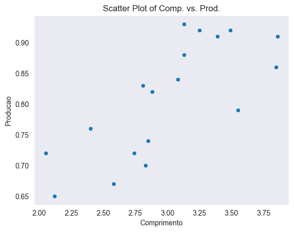

```python
sns.set_style("dark")
sns.scatterplot(data=df, x='Comprimento', y='Producao')
plt.title('Scatter Plot of Comp. vs. Prod.')
# Displaying the plot
plt.show()
```

```python
from scipy.stats import pearsonr

# Calculate Pearson correlation coefficient
corr_coefficient, p_value = pearsonr(df['Comprimento'], df['Producao'], alternative='two-sided')

# Display the correlation coefficient and p-value
print(f"Pearson Correlation Coefficient: {corr_coefficient.round(3)}")
print(f"P-value: {p_value.round(4)}")
```

```
Pearson Correlation Coefficient: 0.756
P-value: 0.0003
```

```python
df.pairwise_corr(method='pearson')
```

|  | X | Y | method | alternative | n | r | CI95% | p-unc | BF10 | power |
| --- | --- | --- | --- | --- | --- | --- | --- | --- | --- | --- |
| 0 | Comprimento | Producao | pearson | two-sided | 18 | 0.7555 | [0.45, 0.9] | 0.0003 | 125.324 | 0.9736 |

## Correlação de Spearman

Uma máquina de Fliperama é usada para medir o aprendizado que resulta de funções manuais repetitivas. Os indivíduos são selecionados de acordo com característica importantes. A tabela ao lado, lista os números de jogos e os últimos escores (em milhões) para os indivíduos selecionados. Precisamos testar se existe uma associação entre o número de jogos e o escore obtido.

| Jogos | Escore |
| --- | --- |
| 9 | 22 |
| 12 | 32 |
| 21 | 70 |
| 6 | 10 |
| 52 | 68 |
| 78 | 73 |
| 33 | 72 |
| 11 | 58 |
| 120 | 75 |

```python
from scipy.stats import spearmanr

# Criar o DataFrame
data = {'Jogos': [9, 12, 21, 6, 52, 78, 33, 11, 120],
        'Escore': [22, 32, 70, 10, 68, 73, 72, 58, 75]}

df = pd.DataFrame(data)
df.head()
```

|  | Jogos | Escore |
| --- | --- | --- |
| 0 | 9 | 22 |
| 1 | 12 | 32 |
| 2 | 21 | 70 |
| 3 | 6 | 10 |
| 4 | 52 | 68 |

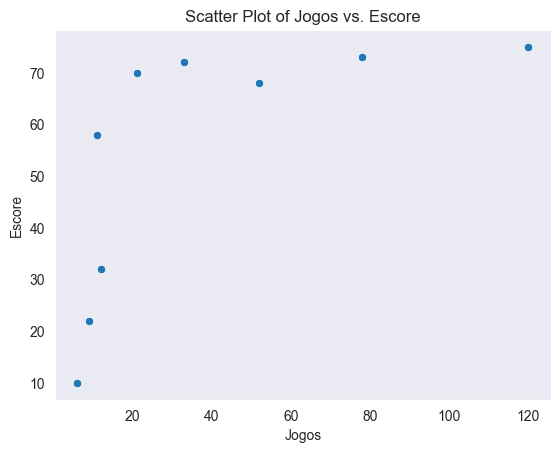

```python
sns.set_style("dark")
sns.scatterplot(data=df, x='Jogos', y='Escore')
plt.title('Scatter Plot of Jogos vs. Escore')
# Displaying the plot
plt.show()
```

```python
# Com a biblioteca Pigouin
df.pairwise_corr(method='spearman')
```

|  | X | Y | method | alternative | n | r | CI95% | p-unc | power |
| --- | --- | --- | --- | --- | --- | --- | --- | --- | --- |
| 0 | Jogos | Escore | spearman | two-sided | 9 | 0.9333 | [0.71, 0.99] | 0.0002 | 0.9892 |

## Correlação de Kendal

Suponha que dois treinadores de basquete classifiquem 12 de seus jogadores, do pior ao melhor. A tabela a seguir mostra as classificações que cada treinador atribuiu aos jogadores:

| Jogador | Treinador1 | Treinador2 |
| --- | --- | --- |
| AJ | 1 | 1 |
| Ben | 2 | 2 |
| Conner | 3 | 3 |
| Duane | 4 | 5 |
| Elliot | 5 | 4 |
| Frank | 6 | 7 |
| Greg | 7 | 6 |
| Hank | 8 | 8 |
| Isaiah | 9 | 10 |
| Jim | 10 | 9 |
| Kurt | 11 | 11 |
| Luke | 12 | 12 |

```python
import pandas as pd

# Criar um DataFrame a partir dos dados fornecidos
data = {
    'Jogador': ['AJ', 'Ben', 'Conner', 'Duane', 'Elliot', 'Frank', 'Greg', 'Hank', 'Isaiah', 'Jim', 'Kurt', 'Luke'],
    'Treinador1': [1, 2, 3, 4, 5, 6, 7, 8, 9, 10, 11, 12],
    'Treinador2': [1, 2, 3, 5, 4, 7, 6, 8, 10, 9, 11, 12]
}

df = pd.DataFrame(data)

# Calcular o coeficiente de correlação de Kendall
df.pairwise_corr(method='kendall')
```

|  | X | Y | method | alternative | n | r | CI95% | p-unc | power |
| --- | --- | --- | --- | --- | --- | --- | --- | --- | --- |
| 0 | Treinador1 | Treinador2 | kendall | two-sided | 12 | 0.9091 | [0.7, 0.97] | 0.0000 | 0.9968 |